# 重賞レース予測レポート【毎時自動更新中】

作成日時: 2025/08/17 15:05:50

☞ [マニュアル(pdf)](https://ryutoro-galois.github.io/keiba-predictor/manual/manual.pdf)

☞ 過去5年の同一レース結果: [2024年](https://ryutoro-galois.github.io/keiba-predictor/report/PredResult_2024y_raceDate_20240818_20240818.html), [2023年](https://ryutoro-galois.github.io/keiba-predictor/report/PredResult_2023y_raceDate_20230813_20230813.html), [2022年](https://ryutoro-galois.github.io/keiba-predictor/report/PredResult_2022y_raceDate_20220814_20220814.html), [2021年](https://ryutoro-galois.github.io/keiba-predictor/report/PredResult_2021y_raceDate_20210815_20210815.html), [2020年](https://ryutoro-galois.github.io/keiba-predictor/report/PredResult_2020y_raceDate_20200816_20200816.html)

☞ 過去4週間の別レース結果: [1週前(8/9-10)](https://ryutoro-galois.github.io/keiba-predictor/report/PredResult_2025y_raceDate_20250809_20250810.html), [2週前(8/3)](https://ryutoro-galois.github.io/keiba-predictor/report/PredResult_2025y_raceDate_20250803_20250803.html), [3週前(7/27)](https://ryutoro-galois.github.io/keiba-predictor/report/PredResult_2025y_raceDate_20250727_20250727.html), [4週前(7/20)](https://ryutoro-galois.github.io/keiba-predictor/report/PredResult_2025y_raceDate_20250720_20250720.html)

☞ netkeiba: [新潟ジャンプステークス(JGⅢ)](https://race.netkeiba.com/race/shutuba.html?race_id=202504020709&rf=race_list), [中京記念(GⅢ)](https://race.netkeiba.com/race/shutuba.html?race_id=202507030807&rf=race_list), [札幌記念(GⅡ)](https://race.netkeiba.com/race/shutuba.html?race_id=202501010811&rf=race_list)

## 0. 推し馬予測 (AI予測)

### 【新潟ジャンプステークス(J.GⅢ) 2025/08/16(土)】

- 本命(◎): 1-3着内確率(勝負強さ)が1位の馬
- 対抗(◯): 1-3着内確率が2-N位(20%程度以上)の中で予測タイムが最も速い馬
- 3番手(▲): 1-3着内確率が2-N位(20%程度以上)のでダークホース確率が最も高い馬
- 穴: ダークホース確率が上位1-M位(40%程度以上)の中で1-3着内確率が最も高い馬

| 推し馬 | 枠番 | 馬番 | 人気 | オッズ | 馬名 | 騎手 | 調教師 | 予測タイム(sec) | 1_順位 | 1-3着内確率(%) | 2_順位 | ﾀﾞｰｸﾎｰｽ確率(%) | 3_順位 |
| --- | --- | --- | --- | --- | --- | --- | --- | --- | --- | --- | --- | --- | --- |
| 本命(◎) | 1 | 1 | 2 | 3.6 | ヒートオンビート | 石神深一 | 青木孝文 | 209.1 | 1.5 | 35.5 | 1 | 0.8 | 12 |
| 対抗(◯) | 3 | 4 | 4 | 10.2 | スコラーリ | 上野翔 | 萩原清 | 224.3 | 10.0 | 21.6 | 3 | 1.0 | 11 |
| 3番手(▲) | 6 | 9 | 3 | 6.1 | サイード | 小坂忠士 | 角田晃一 | 229.6 | 13.0 | 27.0 | 2 | 0.6 | 13 |
| 穴 | 4 | 5 | 8 | 36.9 | マイネルエール | 大江原圭 | 蛯名利弘 | 224.6 | 12.0 | 9.8 | 7 | 55.1 | 3 |

### 【中京記念(GⅢ) 2025/08/17(日)】

- 本命(◎): 1-3着内確率(勝負強さ)が1位の馬
- 対抗(◯): 1-3着内確率が2-N位(20%程度以上)の中で予測タイムが最も速い馬
- 3番手(▲): 1-3着内確率が2-N位(20%程度以上)のでダークホース確率が最も高い馬
- 穴: ダークホース確率が上位1-M位(40%程度以上)の中で1-3着内確率が最も高い馬

| 推し馬 | 枠番 | 馬番 | 人気 | オッズ | 馬名 | 騎手 | 調教師 | 予測タイム(sec) | 1_順位 | 1-3着内確率(%) | 2_順位 | ﾀﾞｰｸﾎｰｽ確率(%) | 3_順位 |
| --- | --- | --- | --- | --- | --- | --- | --- | --- | --- | --- | --- | --- | --- |
| 本命(◎) | 6 | 8 | 2 | 4.4 | エコロヴァルツ | 坂井瑠星 | 牧浦充徳 | 104.4 | 10 | 44.9 | 1 | 0.4 | 11 |
| 対抗(◯) | 1 | 1 | 5 | 7.3 | マピュース | 横山武史 | 和田勇介 | 100.8 | 3 | 27.7 | 3 | 1.6 | 8 |
| 3番手(▲) | 8 | 11 | 4 | 6.0 | キープカルム | 松山弘平 | 中竹和也 | 103.3 | 5 | 32.8 | 2 | 1.7 | 7 |
| 穴 | 5 | 5 | 7 | 19.8 | シンフォーエバー | 松若風馬 | 森秀行 | 100.6 | 2 | 9.4 | 5 | 26.1 | 1 |

### 【札幌記念(GⅡ) 2025/08/17(日)】

- 本命(◎): 1-3着内確率(勝負強さ)が1位の馬
- 対抗(◯): 1-3着内確率が2-N位(20%程度以上)の中で予測タイムが最も速い馬
- 3番手(▲): 1-3着内確率が2-N位(20%程度以上)のでダークホース確率が最も高い馬
- 穴: ダークホース確率が上位1-M位(40%程度以上)の中で1-3着内確率が最も高い馬

| 推し馬 | 枠番 | 馬番 | 人気 | オッズ | 馬名 | 騎手 | 調教師 | 予測タイム(sec) | 1_順位 | 1-3着内確率(%) | 2_順位 | ﾀﾞｰｸﾎｰｽ確率(%) | 3_順位 |
| --- | --- | --- | --- | --- | --- | --- | --- | --- | --- | --- | --- | --- | --- |
| 本命(◎) | 2 | 4 | 6 | 10.3 | コスモキュランダ | 丹内祐次 | 加藤士津八 | 131.9 | 16 | 23.2 | 1 | 0.5 | 14 |
| 対抗(◯) | 3 | 5 | 1 | 3.2 | ホウオウビスケッツ | 岩田康誠 | 奥村武 | 118.7 | 1 | 20.1 | 3 | 0.4 | 16 |
| 3番手(▲) | 4 | 8 | 3 | 6.4 | ステレンボッシュ | 池添謙一 | 国枝栄 | 127.4 | 7 | 21.7 | 2 | 0.8 | 11 |
| 穴 | 6 | 12 | 9 | 22.1 | アルナシーム | 藤岡佑介 | 橋口慎介 | 121.3 | 2 | 12.8 | 9 | 47.8 | 4 |

## 1. 予測チャート (タイム/勝負強さ)

### 【新潟ジャンプステークス(J.GⅢ)】

2025/08/16(土), 04_新潟, 障芝外-内3250m

[interactive chart not shown]

### 【中京記念(GⅢ)】

2025/08/17(日), 07_中京, 芝左1600m

[interactive chart not shown]

### 【札幌記念(GⅡ)】

2025/08/17(日), 01_札幌, 芝右2000m

[interactive chart not shown]

## 2. オッズモニタリング (毎時)

### 【新潟ジャンプステークス】

[interactive chart not shown]

### 【中京記念】

[interactive chart not shown]

### 【札幌記念】

[interactive chart not shown]

## 3. 出馬表

### 【新潟ジャンプステークス 2025/08/16(土) 】

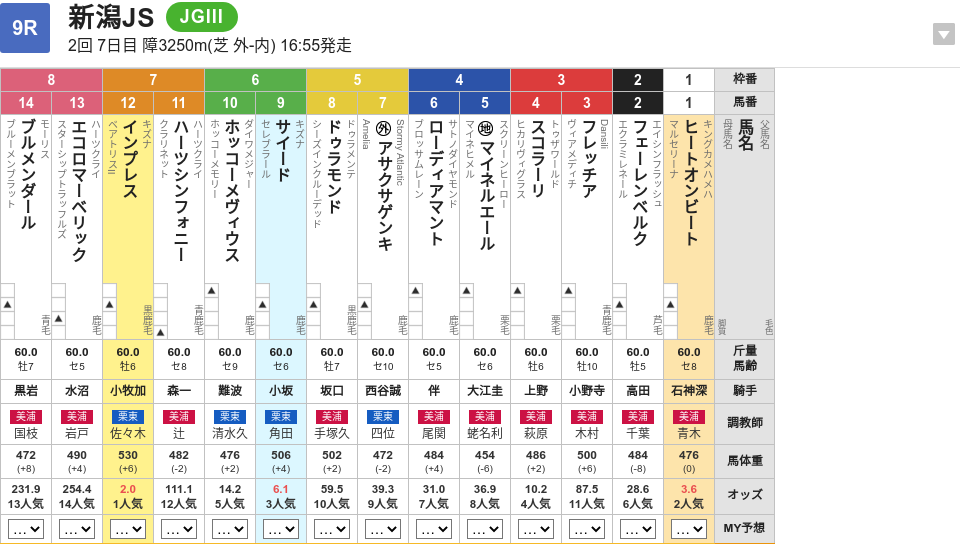

### 【中京記念 2025/08/17(日) 】

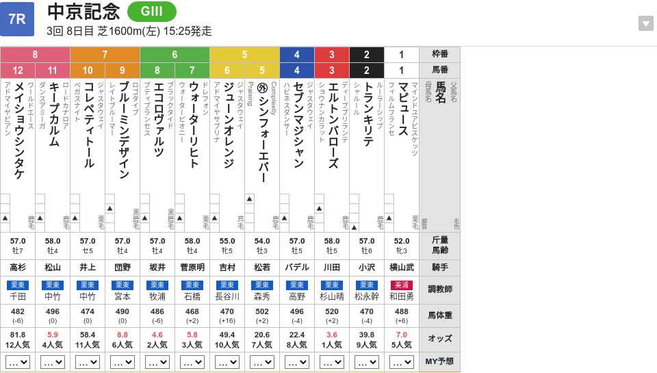

### 【札幌記念 2025/08/17(日) 】

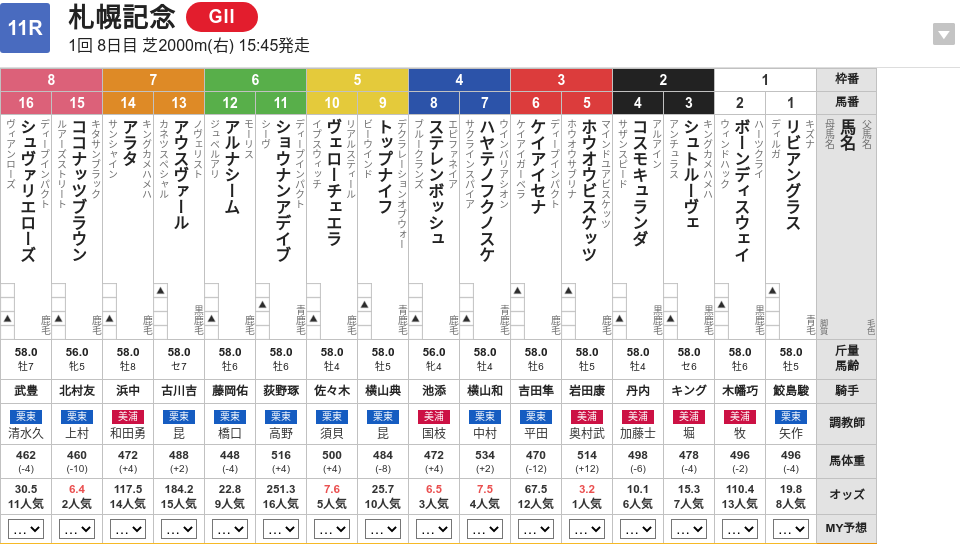

## 4. 単勝予測結果

### 【新潟ジャンプステークス(J.GⅢ) 2025/08/16(土)】

| 枠番 | 馬番 | 人気 | オッズ | 馬名 | 騎手 | 調教師 | 予測タイム(sec) | 1_順位 | 1-3着内確率(%) | 2_順位 | ﾀﾞｰｸﾎｰｽ確率(%) | 3_順位 |
| --- | --- | --- | --- | --- | --- | --- | --- | --- | --- | --- | --- | --- |
| 1 | 1 | 2 | 3.6 | ヒートオンビート | 石神深一 | 青木孝文 | 209.1 | 1.5 | 35.5 | 1 | 0.8 | 12 |
| 2 | 2 | 6 | 28.6 | フェーレンベルク | 高田潤 | 千葉直人 | 224.2 | 9.0 | 11.8 | 6 | 1.9 | 8 |
| 3 | 3 | 11 | 87.5 | フレッチア | 小野寺祐太 | 木村哲也 | 212.1 | 5.0 | 6.8 | 11 | 15.8 | 7 |
| 3 | 4 | 4 | 10.2 | スコラーリ | 上野翔 | 萩原清 | 224.3 | 10.0 | 21.6 | 3 | 1.0 | 11 |
| 4 | 5 | 8 | 36.9 | マイネルエール | 大江原圭 | 蛯名利弘 | 224.6 | 12.0 | 9.8 | 7 | 55.1 | 3 |
| 4 | 6 | 7 | 31.0 | ローディアマント | 伴啓太 | 尾関知人 | 224.5 | 11.0 | 9.3 | 8 | 1.8 | 9 |
| 5 | 7 | 9 | 39.3 | アサクサゲンキ | 西谷誠 | 四位洋文 | 210.6 | 3.0 | 4.4 | 13 | 18.6 | 6 |
| 5 | 8 | 10 | 59.5 | ドゥラモンド | 坂口智康 | 手塚貴久 | 211.1 | 4.0 | 6.3 | 12 | 19.4 | 4 |
| 6 | 9 | 3 | 6.1 | サイード | 小坂忠士 | 角田晃一 | 229.6 | 13.0 | 27.0 | 2 | 0.6 | 13 |
| 6 | 10 | 5 | 14.2 | ホッコーメヴィウス | 難波剛健 | 清水久詞 | 230.6 | 14.0 | 12.0 | 5 | 1.2 | 10 |

[output cut: 4 more lines]

### 【中京記念(GⅢ) 2025/08/17(日)】

| 枠番 | 馬番 | 人気 | オッズ | 馬名 | 騎手 | 調教師 | 予測タイム(sec) | 1_順位 | 1-3着内確率(%) | 2_順位 | ﾀﾞｰｸﾎｰｽ確率(%) | 3_順位 |
| --- | --- | --- | --- | --- | --- | --- | --- | --- | --- | --- | --- | --- |
| 1 | 1 | 5 | 7.3 | マピュース | 横山武史 | 和田勇介 | 100.8 | 3 | 27.7 | 3 | 1.6 | 8 |
| 2 | 2 | 9 | 37.8 | トランキリテ | 小沢大仁 | 松永幹夫 | 103.4 | 7 | 3.7 | 10 | 5.8 | 6 |
| 3 | 3 | 1 | 3.8 | エルトンバローズ | 川田将雅 | 杉山晴紀 | 92.3 | 1 | 7.4 | 7 | 0.4 | 12 |
| 4 | 4 | 8 | 21.9 | セブンマジシャン | Ａ．バデル | 高野友和 | 104.9 | 12 | 6.6 | 8 | 20.6 | 2 |
| 5 | 5 | 7 | 19.8 | シンフォーエバー | 松若風馬 | 森秀行 | 100.6 | 2 | 9.4 | 5 | 26.1 | 1 |
| 5 | 6 | 10 | 48.8 | ジューンオレンジ | 吉村誠之助 | 長谷川浩大 | 103.5 | 8 | 2.7 | 12 | 8.9 | 4 |
| 6 | 7 | 3 | 5.8 | ウォーターリヒト | 菅原明良 | 石橋守 | 104.6 | 11 | 8.8 | 6 | 1.4 | 10 |
| 6 | 8 | 2 | 4.4 | エコロヴァルツ | 坂井瑠星 | 牧浦充徳 | 104.4 | 10 | 44.9 | 1 | 0.4 | 11 |
| 7 | 9 | 6 | 8.4 | ブルーミンデザイン | 団野大成 | 宮本博 | 101.4 | 4 | 20.9 | 4 | 1.6 | 9 |
| 7 | 10 | 11 | 52.3 | コレペティトール | 井上敏樹 | 中竹和也 | 103.6 | 9 | 2.9 | 11 | 15.4 | 3 |

[output cut: 2 more lines]

### 【札幌記念(GⅡ) 2025/08/17(日)】

| 枠番 | 馬番 | 人気 | オッズ | 馬名 | 騎手 | 調教師 | 予測タイム(sec) | 1_順位 | 1-3着内確率(%) | 2_順位 | ﾀﾞｰｸﾎｰｽ確率(%) | 3_順位 |
| --- | --- | --- | --- | --- | --- | --- | --- | --- | --- | --- | --- | --- |
| 1 | 1 | 8 | 20.0 | リビアングラス | 鮫島克駿 | 矢作芳人 | 131.8 | 15 | 13.3 | 7 | 1.9 | 9 |
| 1 | 2 | 13 | 109.9 | ボーンディスウェイ | 木幡巧也 | 牧光二 | 125.9 | 6 | 3.3 | 14 | 26.5 | 7 |
| 2 | 3 | 7 | 15.7 | シュトルーヴェ | Ｒ．キング | 堀宣行 | 131.3 | 14 | 13.2 | 8 | 1.6 | 10 |
| 2 | 4 | 6 | 10.3 | コスモキュランダ | 丹内祐次 | 加藤士津八 | 131.9 | 16 | 23.2 | 1 | 0.5 | 14 |
| 3 | 5 | 1 | 3.2 | ホウオウビスケッツ | 岩田康誠 | 奥村武 | 118.7 | 1 | 20.1 | 3 | 0.4 | 16 |
| 3 | 6 | 12 | 65.8 | ケイアイセナ | 吉田隼人 | 平田修 | 129.2 | 10 | 8.3 | 11 | 50.5 | 2 |
| 4 | 7 | 5 | 7.8 | ハヤテノフクノスケ | 横山和生 | 中村直也 | 130.4 | 12 | 18.6 | 4 | 0.5 | 13 |
| 4 | 8 | 3 | 6.4 | ステレンボッシュ | 池添謙一 | 国枝栄 | 127.4 | 7 | 21.7 | 2 | 0.8 | 11 |
| 5 | 9 | 10 | 25.7 | トップナイフ | 横山典弘 | 昆貢 | 125.3 | 5 | 7.5 | 12 | 20.1 | 8 |
| 5 | 10 | 4 | 7.7 | ヴェローチェエラ | 佐々木大輔 | 須貝尚介 | 130.5 | 13 | 16.9 | 6 | 0.5 | 15 |

[output cut: 6 more lines]

## 5. 人気と着順の乖離率推移

### 【新潟ジャンプステークス_1999y_2019y】

[interactive chart not shown]

### 【中京記念_1990y_2019y】

[interactive chart not shown]

### 【札幌記念_1990y_2019y】

[interactive chart not shown]

### 【新潟ジャンプステークス_1999y_2019y】

| No | 開催年 | 不整合率(%) | 頭数 | 人気別着順(1-3位) | 人気別着順(全体) |
| --- | --- | --- | --- | --- | --- |
| 21 | 2019 | 36.8 | 11頭 | 3-1-6 | 3\|1\|6\|2\|7\|4\|8\|11\|10\|9\|5 |
| 20 | 2018 | 43.5 | 12頭 | 2-8-7 | 2\|8\|7\|5\|1\|6\|11\|9\|10\|12\|4\|13 |
| 19 | 2017 | 47.9 | 11頭 | 3-2-8 | 3\|2\|8\|1\|7\|4\|11\|5\|6\|10\|9 |
| 18 | 2016 | 57.1 | 14頭 | 3-2-10 | 3\|2\|10\|7\|8\|5\|6\|1\|14\|9\|12\|13\|4\|11 |
| 17 | 2015 | 32.0 | 14頭 | 8-2-1 | 8\|2\|1\|5\|4\|7\|3\|6\|10\|9\|12\|13\|14\|11 |
| 16 | 2014 | 23.5 | 12頭 | 1-4-8 | 1\|4\|8\|2\|5\|7\|6\|3\|12\|10\|9\|11 |
| 15 | 2013 | 37.5 | 14頭 | 3-1-10 | 3\|1\|10\|5\|2\|14\|4\|8\|9\|11\|12\|7\|13\|6 |
| 14 | 2012 | 46.4 | 13頭 | 3-2-4 | 3\|2\|4\|1\|6\|7\|5\|10\|11\|13\|8\|14\|12 |
| 13 | 2011 | 47.8 | 14頭 | 3-2-1 | 3\|2\|1\|10\|12\|6\|9\|11\|4\|13\|8\|14\|5\|7 |
| 12 | 2010 | 26.1 | 14頭 | 1-12-4 | 1\|12\|4\|2\|8\|5\|9\|7\|10\|13\|6\|11\|3\|14 |

[output cut: 11 more lines]

### 【中京記念_1990y_2019y】

| No | 開催年 | 不整合率(%) | 頭数 | 人気別着順(1-3位) | 人気別着順(全体) |
| --- | --- | --- | --- | --- | --- |
| 30 | 2019 | 42.7 | 16頭 | 3-6-1 | 3\|6\|1\|4\|9\|11\|8\|2\|7\|10\|5\|14\|15\|13\|16\|12 |
| 29 | 2018 | 38.8 | 16頭 | 1-5-4 | 1\|5\|4\|7\|3\|13\|6\|2\|15\|10\|11\|9\|12\|14\|8\|16 |
| 28 | 2017 | 35.3 | 16頭 | 5-2-1 | 5\|2\|1\|4\|3\|16\|14\|15\|11\|7\|13\|8\|10\|12\|9\|6 |
| 27 | 2016 | 48.2 | 16頭 | 7-6-4 | 7\|6\|4\|16\|5\|10\|14\|11\|9\|1\|15\|2\|13\|12\|3\|8 |
| 26 | 2015 | 48.2 | 16頭 | 6-13-3 | 6\|13\|3\|15\|8\|7\|1\|2\|16\|10\|12\|5\|11\|14\|4\|9 |
| 25 | 2014 | 65.7 | 16頭 | 7-11-5 | 7\|11\|5\|6\|10\|16\|3\|2\|15\|1\|4\|9\|13\|8\|14\|12 |
| 24 | 2013 | 63.6 | 15頭 | 5-13-3 | 5\|13\|3\|2\|6\|9\|12\|10\|8\|1\|16\|14\|15\|11\|7 |
| 23 | 2012 | 53.7 | 16頭 | 5-6-10 | 5\|6\|10\|7\|9\|3\|1\|15\|13\|14\|2\|16\|12\|4\|8\|11 |
| 22 | 2011 | 52.2 | 16頭 | 2-8-12 | 2\|8\|12\|10\|3\|15\|14\|6\|9\|11\|13\|7\|5\|16\|1\|4 |
| 21 | 2010 | 59.0 | 18頭 | 4-12-15 | 4\|12\|15\|11\|7\|3\|5\|1\|10\|9\|6\|17\|18\|2\|16\|8\|14\|13 |

[output cut: 20 more lines]

### 【札幌記念_1990y_2019y】

| No | 開催年 | 不整合率(%) | 頭数 | 人気別着順(1-3位) | 人気別着順(全体) |
| --- | --- | --- | --- | --- | --- |
| 30 | 2019 | 38.3 | 14頭 | 3-4-1 | 3\|4\|1\|2\|5\|11\|6\|9\|8\|10\|13\|14\|12\|7 |
| 29 | 2018 | 32.4 | 16頭 | 2-1-4 | 2\|1\|4\|13\|12\|7\|8\|11\|6\|15\|14\|10\|3\|5\|9\|16 |
| 28 | 2017 | 27.6 | 13頭 | 6-12-1 | 6\|12\|1\|4\|2\|5\|9\|3\|7\|13\|11\|10\|8 |
| 27 | 2016 | 26.0 | 16頭 | 5-1-4 | 5\|1\|4\|2\|3\|12\|14\|15\|11\|6\|16\|7\|8\|13\|9\|10 |
| 26 | 2015 | 60.6 | 15頭 | 5-8-4 | 5\|8\|4\|10\|2\|3\|7\|1\|6\|11\|12\|14\|13\|9\|15 |
| 25 | 2014 | 36.7 | 14頭 | 2-1-7 | 2\|1\|7\|6\|5\|13\|12\|4\|8\|9\|3\|14\|10\|11 |
| 24 | 2013 | 42.4 | 16頭 | 2-8-14 | 2\|8\|14\|6\|1\|11\|5\|7\|12\|15\|10\|16\|4\|9\|3\|13 |
| 23 | 2012 | 28.4 | 14頭 | 4-1-2 | 4\|1\|2\|5\|9\|11\|8\|6\|10\|13\|3\|14\|12\|7 |
| 22 | 2011 | 28.6 | 13頭 | 1-5-2 | 1\|5\|2\|8\|7\|9\|6\|12\|10\|4\|11\|3\|13 |
| 21 | 2010 | 21.1 | 16頭 | 1-5-7 | 1\|5\|7\|2\|4\|3\|6\|16\|11\|14\|13\|8\|10\|9\|12\|15 |

[output cut: 20 more lines]

## 6. 1-3番人気馬の着順分類予測

### 【新潟ジャンプステークス】

| 分類 | 凡例 | 発生確率(%) | 当該レース | 当該レースランク | 直近1年間 |
| --- | --- | --- | --- | --- | --- |
| 1: 1番人気のみ (1_pop1) | 1 \| * \| * | 17.6 | 1.14 | 0.85 | 0.00 |
| 4: 1,2番人気のみ (4_pop12) | 1 \| 2 \| * | 16.5 | 2.14 | 3.75 | 0.00 |
| 5: 1,3番人気のみ (5_pop13) | 1 \| 3 \| * | 15.5 | 0.50 | 0.66 | 0.15 |
| 8: 1,2,3番人気すべて着外 (8_darkhorse) | * \| * \| * | 14.2 | 0.92 | 0.64 | 0.00 |
| 6: 2,3番人気のみ (6_pop23) | 2 \| 3 \| * | 9.9 | 0.52 | 0.96 | 0.00 |
| 2: 2番人気のみ (2_pop2) | 2 \| * \| * | 9.8 | 1.27 | 0.95 | 0.00 |
| 3: 3番人気のみ (3_pop3) | 3 \| * \| * | 9.4 | 0.00 | 1.27 | 0.00 |
| 7: 1,2,3番人気すべて着内 (7_pop123) | 1 \| 2 \| 3 | 7.1 | 1.87 | 4.73 | 0.00 |

### 【中京記念】

| 分類 | 凡例 | 発生確率(%) | 当該レース | 当該レースランク | 直近1年間 |
| --- | --- | --- | --- | --- | --- |
| 1: 1番人気のみ (1_pop1) | 1 \| * \| * | 17.6 | 0.88 | 0.74 | 0.00 |
| 4: 1,2番人気のみ (4_pop12) | 1 \| 2 \| * | 16.5 | 5.69 | 6.88 | 0.00 |
| 5: 1,3番人気のみ (5_pop13) | 1 \| 3 \| * | 15.5 | 0.68 | 0.82 | 0.15 |
| 8: 1,2,3番人気すべて着外 (8_darkhorse) | * \| * \| * | 14.2 | 0.62 | 0.54 | 0.00 |
| 6: 2,3番人気のみ (6_pop23) | 2 \| 3 \| * | 9.9 | 1.74 | 2.06 | 0.00 |
| 2: 2番人気のみ (2_pop2) | 2 \| * \| * | 9.8 | 0.86 | 0.82 | 0.00 |
| 3: 3番人気のみ (3_pop3) | 3 \| * \| * | 9.4 | 0.66 | 0.79 | 0.00 |
| 7: 1,2,3番人気すべて着内 (7_pop123) | 1 \| 2 \| 3 | 7.1 | 0.00 | 0.00 | 0.00 |

### 【札幌記念】

| 分類 | 凡例 | 発生確率(%) | 当該レース | 当該レースランク | 直近1年間 |
| --- | --- | --- | --- | --- | --- |
| 1: 1番人気のみ (1_pop1) | 1 \| * \| * | 17.6 | 0.88 | 1.23 | 0.00 |
| 4: 1,2番人気のみ (4_pop12) | 1 \| 2 \| * | 16.6 | 0.65 | 0.52 | 0.00 |
| 5: 1,3番人気のみ (5_pop13) | 1 \| 3 \| * | 15.5 | 0.68 | 0.54 | 0.15 |
| 8: 1,2,3番人気すべて着外 (8_darkhorse) | * \| * \| * | 14.2 | 0.99 | 2.00 | 0.00 |
| 6: 2,3番人気のみ (6_pop23) | 2 \| 3 \| * | 9.9 | 0.00 | 0.00 | 0.00 |
| 2: 2番人気のみ (2_pop2) | 2 \| * \| * | 9.8 | 1.14 | 1.38 | 0.00 |
| 3: 3番人気のみ (3_pop3) | 3 \| * \| * | 9.4 | 3.24 | 2.61 | 0.00 |
| 7: 1,2,3番人気すべて着内 (7_pop123) | 1 \| 2 \| 3 | 7.1 | 1.25 | 1.00 | 0.00 |

## 7. 3連複予測結果

### 【新潟ジャンプステークス(J.GⅢ) 2025/08/16(土)】

| 分類 | 馬番 | 枠番 | 人気 | 平均予測タイム(sec) | 1-3着内確率(%) | ﾀﾞｰｸﾎｰｽ確率(%) | 馬名 | 騎手 | 調教師 |
| --- | --- | --- | --- | --- | --- | --- | --- | --- | --- |
| 6: 2,3番人気のみ (6_pop23) | 1-9-4 | 1-6-3 | 2-3-4 | 221.00 | 2.07 | 0.00 | ヒートオンビート \| サイード \| スコラーリ | 石神深一 \| 小坂忠士 \| 上野翔 | 青木孝文 \| 角田晃一 \| 萩原清 |
| 7: 1,2,3番人気すべて着内 (7_pop123) | 12-1-9 | 7-1-6 | 1-2-3 | 215.93 | 1.55 | 0.00 | インプレス \| ヒートオンビート \| サイード | 小牧加矢太 \| 石神深一 \| 小坂忠士 | 佐々木晶三 \| 青木孝文 \| 角田晃一 |
| 4: 1,2番人気のみ (4_pop12) | 12-1-4 | 7-1-3 | 1-2-4 | 214.17 | 1.24 | 0.00 | インプレス \| ヒートオンビート \| スコラーリ | 小牧加矢太 \| 石神深一 \| 上野翔 | 佐々木晶三 \| 青木孝文 \| 萩原清 |
| 6: 2,3番人気のみ (6_pop23) | 1-9-10 | 1-6-6 | 2-3-5 | 223.10 | 1.15 | 0.00 | ヒートオンビート \| サイード \| ホッコーメヴィウス | 石神深一 \| 小坂忠士 \| 難波剛健 | 青木孝文 \| 角田晃一 \| 清水久詞 |
| 6: 2,3番人気のみ (6_pop23) | 1-9-2 | 1-6-2 | 2-3-6 | 220.97 | 1.13 | 0.00 | ヒートオンビート \| サイード \| フェーレンベルク | 石神深一 \| 小坂忠士 \| 高田潤 | 青木孝文 \| 角田晃一 \| 千葉直人 |
| 6: 2,3番人気のみ (6_pop23) | 1-9-5 | 1-6-4 | 2-3-8 | 221.10 | 0.94 | 0.00 | ヒートオンビート \| サイード \| マイネルエール | 石神深一 \| 小坂忠士 \| 大江原圭 | 青木孝文 \| 角田晃一 \| 蛯名利弘 |
| 5: 1,3番人気のみ (5_pop13) | 12-9-4 | 7-6-3 | 1-3-4 | 221.00 | 0.94 | 0.00 | インプレス \| サイード \| スコラーリ | 小牧加矢太 \| 小坂忠士 \| 上野翔 | 佐々木晶三 \| 角田晃一 \| 萩原清 |
| 2: 2番人気のみ (2_pop2) | 1-4-10 | 1-3-6 | 2-4-5 | 221.33 | 0.92 | 0.00 | ヒートオンビート \| スコラーリ \| ホッコーメヴィウス | 石神深一 \| 上野翔 \| 難波剛健 | 青木孝文 \| 萩原清 \| 清水久詞 |
| 2: 2番人気のみ (2_pop2) | 1-4-2 | 1-3-2 | 2-4-6 | 219.20 | 0.91 | 0.00 | ヒートオンビート \| スコラーリ \| フェーレンベルク | 石神深一 \| 上野翔 \| 高田潤 | 青木孝文 \| 萩原清 \| 千葉直人 |
| 6: 2,3番人気のみ (6_pop23) | 1-9-6 | 1-6-4 | 2-3-7 | 221.07 | 0.89 | 0.00 | ヒートオンビート \| サイード \| ローディアマント | 石神深一 \| 小坂忠士 \| 伴啓太 | 青木孝文 \| 角田晃一 \| 尾関知人 |

[output cut: 354 more lines]

### 【中京記念(GⅢ) 2025/08/17(日)】

| 分類 | 馬番 | 枠番 | 人気 | 平均予測タイム(sec) | 1-3着内確率(%) | ﾀﾞｰｸﾎｰｽ確率(%) | 馬名 | 騎手 | 調教師 |
| --- | --- | --- | --- | --- | --- | --- | --- | --- | --- |
| 2: 2番人気のみ (2_pop2) | 8-11-1 | 6-8-1 | 2-4-5 | 102.83 | 4.09 | 0.00 | エコロヴァルツ \| キープカルム \| マピュース | 坂井瑠星 \| 松山弘平 \| 横山武史 | 牧浦充徳 \| 中竹和也 \| 和田勇介 |
| 2: 2番人気のみ (2_pop2) | 8-11-9 | 6-8-7 | 2-4-6 | 103.03 | 3.08 | 0.00 | エコロヴァルツ \| キープカルム \| ブルーミンデザイン | 坂井瑠星 \| 松山弘平 \| 団野大成 | 牧浦充徳 \| 中竹和也 \| 宮本博 |
| 2: 2番人気のみ (2_pop2) | 8-1-9 | 6-1-7 | 2-5-6 | 102.20 | 2.60 | 0.00 | エコロヴァルツ \| マピュース \| ブルーミンデザイン | 坂井瑠星 \| 横山武史 \| 団野大成 | 牧浦充徳 \| 和田勇介 \| 宮本博 |
| 8: 1,2,3番人気すべて着外 (8_darkhorse) | 11-1-9 | 8-1-7 | 4-5-6 | 101.83 | 1.90 | 0.00 | キープカルム \| マピュース \| ブルーミンデザイン | 松山弘平 \| 横山武史 \| 団野大成 | 中竹和也 \| 和田勇介 \| 宮本博 |
| 2: 2番人気のみ (2_pop2) | 8-11-5 | 6-8-5 | 2-4-7 | 102.77 | 1.39 | 0.00 | エコロヴァルツ \| キープカルム \| シンフォーエバー | 坂井瑠星 \| 松山弘平 \| 松若風馬 | 牧浦充徳 \| 中竹和也 \| 森秀行 |
| 6: 2,3番人気のみ (6_pop23) | 8-7-11 | 6-6-8 | 2-3-4 | 104.10 | 1.30 | 0.00 | エコロヴァルツ \| ウォーターリヒト \| キープカルム | 坂井瑠星 \| 菅原明良 \| 松山弘平 | 牧浦充徳 \| 石橋守 \| 中竹和也 |
| 2: 2番人気のみ (2_pop2) | 8-1-5 | 6-1-5 | 2-5-7 | 101.93 | 1.18 | 0.00 | エコロヴァルツ \| マピュース \| シンフォーエバー | 坂井瑠星 \| 横山武史 \| 松若風馬 | 牧浦充徳 \| 和田勇介 \| 森秀行 |
| 6: 2,3番人気のみ (6_pop23) | 8-7-1 | 6-6-1 | 2-3-5 | 103.27 | 1.10 | 0.00 | エコロヴァルツ \| ウォーターリヒト \| マピュース | 坂井瑠星 \| 菅原明良 \| 横山武史 | 牧浦充徳 \| 石橋守 \| 和田勇介 |
| 4: 1,2番人気のみ (4_pop12) | 3-8-11 | 3-6-8 | 1-2-4 | 100.00 | 1.09 | 0.00 | エルトンバローズ \| エコロヴァルツ \| キープカルム | 川田将雅 \| 坂井瑠星 \| 松山弘平 | 杉山晴紀 \| 牧浦充徳 \| 中竹和也 |
| 2: 2番人気のみ (2_pop2) | 8-11-4 | 6-8-4 | 2-4-8 | 104.20 | 0.97 | 0.00 | エコロヴァルツ \| キープカルム \| セブンマジシャン | 坂井瑠星 \| 松山弘平 \| Ａ．バデル | 牧浦充徳 \| 中竹和也 \| 高野友和 |

[output cut: 210 more lines]

### 【札幌記念(GⅡ) 2025/08/17(日)】

| 分類 | 馬番 | 枠番 | 人気 | 平均予測タイム(sec) | 1-3着内確率(%) | ﾀﾞｰｸﾎｰｽ確率(%) | 馬名 | 騎手 | 調教師 |
| --- | --- | --- | --- | --- | --- | --- | --- | --- | --- |
| 5: 1,3番人気のみ (5_pop13) | 5-8-4 | 3-4-2 | 1-3-6 | 126.00 | 1.01 | 0.00 | ホウオウビスケッツ \| ステレンボッシュ \| コスモキュランダ | 岩田康誠 \| 池添謙一 \| 丹内祐次 | 奥村武 \| 国枝栄 \| 加藤士津八 |
| 3: 3番人気のみ (3_pop3) | 8-7-4 | 4-4-2 | 3-5-6 | 129.90 | 0.94 | 0.00 | ステレンボッシュ \| ハヤテノフクノスケ \| コスモキュランダ | 池添謙一 \| 横山和生 \| 丹内祐次 | 国枝栄 \| 中村直也 \| 加藤士津八 |
| 6: 2,3番人気のみ (6_pop23) | 15-8-4 | 8-4-2 | 2-3-6 | 129.60 | 0.90 | 0.00 | ココナッツブラウン \| ステレンボッシュ \| コスモキュランダ | 北村友一 \| 池添謙一 \| 丹内祐次 | 上村洋行 \| 国枝栄 \| 加藤士津八 |
| 1: 1番人気のみ (1_pop1) | 5-7-4 | 3-4-2 | 1-5-6 | 127.00 | 0.87 | 0.00 | ホウオウビスケッツ \| ハヤテノフクノスケ \| コスモキュランダ | 岩田康誠 \| 横山和生 \| 丹内祐次 | 奥村武 \| 中村直也 \| 加藤士津八 |
| 3: 3番人気のみ (3_pop3) | 8-10-4 | 4-5-2 | 3-4-6 | 129.93 | 0.85 | 0.00 | ステレンボッシュ \| ヴェローチェエラ \| コスモキュランダ | 池添謙一 \| 佐々木大輔 \| 丹内祐次 | 国枝栄 \| 須貝尚介 \| 加藤士津八 |
| 4: 1,2番人気のみ (4_pop12) | 5-15-4 | 3-8-2 | 1-2-6 | 126.70 | 0.84 | 0.00 | ホウオウビスケッツ \| ココナッツブラウン \| コスモキュランダ | 岩田康誠 \| 北村友一 \| 丹内祐次 | 奥村武 \| 上村洋行 \| 加藤士津八 |
| 5: 1,3番人気のみ (5_pop13) | 5-8-7 | 3-4-4 | 1-3-5 | 125.50 | 0.81 | 0.00 | ホウオウビスケッツ \| ステレンボッシュ \| ハヤテノフクノスケ | 岩田康誠 \| 池添謙一 \| 横山和生 | 奥村武 \| 国枝栄 \| 中村直也 |
| 1: 1番人気のみ (1_pop1) | 5-10-4 | 3-5-2 | 1-4-6 | 127.03 | 0.79 | 0.00 | ホウオウビスケッツ \| ヴェローチェエラ \| コスモキュランダ | 岩田康誠 \| 佐々木大輔 \| 丹内祐次 | 奥村武 \| 須貝尚介 \| 加藤士津八 |
| 7: 1,2,3番人気すべて着内 (7_pop123) | 5-15-8 | 3-8-4 | 1-2-3 | 125.20 | 0.78 | 0.00 | ホウオウビスケッツ \| ココナッツブラウン \| ステレンボッシュ | 岩田康誠 \| 北村友一 \| 池添謙一 | 奥村武 \| 上村洋行 \| 国枝栄 |
| 2: 2番人気のみ (2_pop2) | 15-7-4 | 8-4-2 | 2-5-6 | 130.60 | 0.78 | 0.00 | ココナッツブラウン \| ハヤテノフクノスケ \| コスモキュランダ | 北村友一 \| 横山和生 \| 丹内祐次 | 上村洋行 \| 中村直也 \| 加藤士津八 |

[output cut: 550 more lines]

## 8. 直近の全レース情報

[output not shown]